# 第一讲：ggplot

林子子 张悦

2017年9月20日

# 1 R编程简介

## 1.1 基本算数

```r
1+1
```

```
## [1] 2
```

```r
1+2+3
```

```
## [1] 6
```

```r
3*7*4
```

```
## [1] 84
```

```r
4/3
```

```
## [1] 1.333333
```

## 1.2 变量

**变量赋值**

```r
x<-1
y=5
a<-b<-6
a
```

```
## [1] 6
```

```r
b
```

```
## [1] 6
```

```r
assign("j",2)
j
```

```
## [1] 2
```

**消除变量**

```r
rm(j)
```

## 1.3 数据类型

**数值型**

```r
class(x)
```

```
## [1] "numeric"
```

```r
is.numeric(x)
```

```
## [1] TRUE
```

```r
i=3L
is.integer(i)
```

```
## [1] TRUE
```

```r
is.numeric(i)
```

```
## [1] TRUE
```

**字符型**

```r
x="name"
x
```

```
## [1] "name"
```

```r
y=factor("name")
y
```

```
## [1] name
## Levels: name
```

```r
nchar(x)
```

```
## [1] 4
```

**逻辑型**

```r
TRUE*5
```

```
## [1] 5
```

```r
FALSE*5
```

```
## [1] 0
```

```r
k=TRUE
class(k)
```

```
## [1] "logical"
```

```r
is.logical(k)
```

```
## [1] TRUE
```

```r
2==3
```

```
## [1] FALSE
```

```r
2!=3
```

```
## [1] TRUE
```

```r
2<3
```

```
## [1] TRUE
```

```r
2<=3
```

```
## [1] TRUE
```

```r
"data"=="name"
```

```
## [1] FALSE
```

## 1.4 数据结构

**向量**

```r
x=c(1,2,3,4,5,6)
x
```

```
## [1] 1 2 3 4 5 6
```

```r
x*2
```

```
## [1]  2  4  6  8 10 12
```

```r
x+2
```

```
## [1] 3 4 5 6 7 8
```

```r
sqrt(x)
```

```
## [1] 1.000000 1.414214 1.732051 2.000000 2.236068 2.449490
```

```r
10:1
```

```
##  [1] 10  9  8  7  6  5  4  3  2  1
```

```r
seq(-2,3,1)
```

```
## [1] -2 -1  0  1  2  3
```

```r
x+y
```

```
## [1] NA NA NA NA NA NA
```

```r
x*y
```

```
## [1] NA NA NA NA NA NA
```

```r
x^y
```

```
## [1] NA NA NA NA NA NA
```

```r
x[1]
```

```
## [1] 1
```

```r
x[1:3]
```

```
## [1] 1 2 3
```

```r
x[c(1,4)]
```

```
## [1] 1 4
```

**data.frames**

```r
x=10:1
y=-4:5
q = c("Hockey","Football","Baseball","Curling","Rugby","Lacrosse","Basketball","Tennis","Cricket","Soccer")
MyData=data.frame(x,y,q)
MyData
```

```
##     x  y          q
## 1  10 -4     Hockey
## 2   9 -3   Football
## 3   8 -2   Baseball
## 4   7 -1    Curling
## 5   6  0      Rugby
## 6   5  1   Lacrosse
## 7   4  2 Basketball
## 8   3  3     Tennis
## 9   2  4    Cricket
## 10  1  5     Soccer
```

```r
MyData=data.frame(First=x,Second=y,Sport=q)
MyData
```

```
##    First Second      Sport
## 1     10     -4     Hockey
## 2      9     -3   Football
## 3      8     -2   Baseball
## 4      7     -1    Curling
## 5      6      0      Rugby
## 6      5      1   Lacrosse
## 7      4      2 Basketball
## 8      3      3     Tennis
## 9      2      4    Cricket
## 10     1      5     Soccer
```

```r
nrow(MyData)#行数
```

```
## [1] 10
```

```r
ncol(MyData)#列数
```

```
## [1] 3
```

```r
dim(MyData)#数据的行数和列数
```

```
## [1] 10  3
```

```r
names(MyData)#列名称
```

```
## [1] "First"  "Second" "Sport"
```

```r
names(MyData)[1] #第一列名称
```

```
## [1] "First"
```

```r
rownames(MyData)
```

```
##  [1] "1"  "2"  "3"  "4"  "5"  "6"  "7"  "8"  "9"  "10"
```

```r
rownames(MyData)=c("One","Two","Three","Four","Five","Six","Seven","Eight","Nine","Ten")
MyData$Sport
```

```
##  [1] Hockey     Football   Baseball   Curling    Rugby      Lacrosse
##  [7] Basketball Tennis     Cricket    Soccer
## 10 Levels: Baseball Basketball Cricket Curling Football ... Tennis
```

```r
MyData[,3]
```

```
##  [1] Hockey     Football   Baseball   Curling    Rugby      Lacrosse
##  [7] Basketball Tennis     Cricket    Soccer
## 10 Levels: Baseball Basketball Cricket Curling Football ... Tennis
```

```r
MyData[,2]
```

```
##  [1] -4 -3 -2 -1  0  1  2  3  4  5
```

**Lists**

```r
list(1,2,3)
```

```
## [[1]]
## [1] 1
##
## [[2]]
## [1] 2
##
## [[3]]
## [1] 3
```

```r
list(c(1,2,3))
```

```
## [[1]]
## [1] 1 2 3
```

```r
list(MyData,1:4)
```

```
## [[1]]
##       First Second      Sport
## One      10     -4     Hockey
## Two       9     -3   Football
## Three     8     -2   Baseball
## Four      7     -1    Curling
## Five      6      0      Rugby
## Six       5      1   Lacrosse
## Seven     4      2 Basketball
## Eight     3      3     Tennis
## Nine      2      4    Cricket
## Ten       1      5     Soccer
##
## [[2]]
## [1] 1 2 3 4
```

**Matrices**

```r
A=matrix(1:9,nrow = 3)
A
```

```
##      [,1] [,2] [,3]
## [1,]    1    4    7
## [2,]    2    5    8
## [3,]    3    6    9
```

```r
B=matrix(10:18,nrow=3)
A+B
```

```
##      [,1] [,2] [,3]
## [1,]   11   17   23
## [2,]   13   19   25
## [3,]   15   21   27
```

```r
A*B ##矩阵元素对应相乘
```

```
##      [,1] [,2] [,3]
## [1,]   10   52  112
## [2,]   22   70  136
## [3,]   36   90  162
```

```r
A%*%B #矩阵乘法运算AB
```

```
##      [,1] [,2] [,3]
## [1,]  138  174  210
## [2,]  171  216  261
## [3,]  204  258  312
```

**读入数据**

```r
theUrl="http://www.jaredlander.com/data/Tomato%20First.csv"
tomato=read.csv(file=theUrl)
head(tomato)
```

```
##   Round             Tomato Price      Source Sweet Acid Color Texture
## 1     1         Simpson SM  3.99 Whole Foods   2.8  2.8   3.7     3.4
## 2     1  Tuttorosso (blue)  2.99     Pioneer   3.3  2.8   3.4     3.0
## 3     1 Tuttorosso (green)  0.99     Pioneer   2.8  2.6   3.3     2.8
## 4     1     La Fede SM DOP  3.99   Shop Rite   2.6  2.8   3.0     2.3
## 5     2       Cento SM DOP  5.49  D Agostino   3.3  3.1   2.9     2.8
## 6     2      Cento Organic  4.99  D Agostino   3.2  2.9   2.9     3.1
##   Overall Avg.of.Totals Total.of.Avg
## 1     3.4          16.1         16.1
## 2     2.9          15.3         15.3
## 3     2.9          14.3         14.3
## 4     2.8          13.4         13.4
## 5     3.1          14.4         15.2
## 6     2.9          15.5         15.1
```

```r
require(XML) ## or library(XML)
#theURL="http://www.jaredlander.com/2012/02/another-kind-of-super-bowl-pool/"
#bowPool=readHTMLTable(theURL,which=1,header=FALSE,stringA$Factors=FLASE) ##which 用来指明第几次表格
#write.csv(bowlPool,"bowlPool.csv")
```

# 2 简单画图

```r
library(coefplot)
data("diamonds")
head(diamonds)
```

```
## # A tibble: 6 x 10
##   carat       cut color clarity depth table price     x     y     z
##   <dbl>     <ord> <ord>   <ord> <dbl> <dbl> <int> <dbl> <dbl> <dbl>
## 1  0.23     Ideal     E     SI2  61.5    55   326  3.95  3.98  2.43
## 2  0.21   Premium     E     SI1  59.8    61   326  3.89  3.84  2.31
## 3  0.23      Good     E     VS1  56.9    65   327  4.05  4.07  2.31
## 4  0.29   Premium     I     VS2  62.4    58   334  4.20  4.23  2.63
## 5  0.31      Good     J     SI2  63.3    58   335  4.34  4.35  2.75
## 6  0.24 Very Good     J    VVS2  62.8    57   336  3.94  3.96  2.48
```

*直方图*

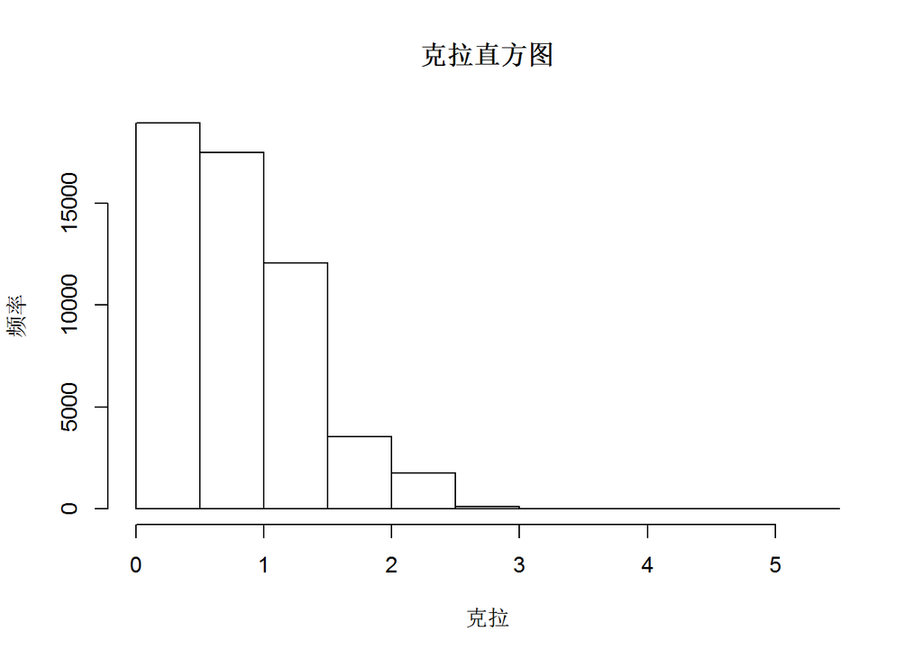

```r
hist(diamonds$carat,main="克拉直方图",xlab="克拉",ylab="频率")
```

*散点图*

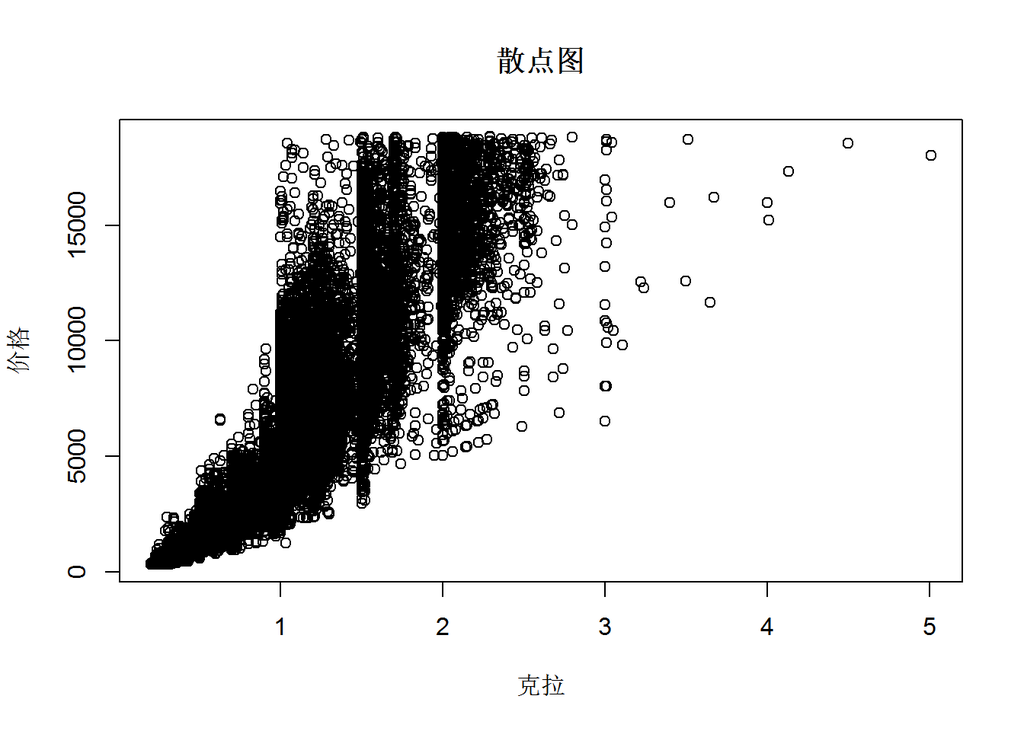

```r
plot(price~carat,data=diamonds,xlab="克拉",ylab="价格",main="散点图")
```

*箱线图*

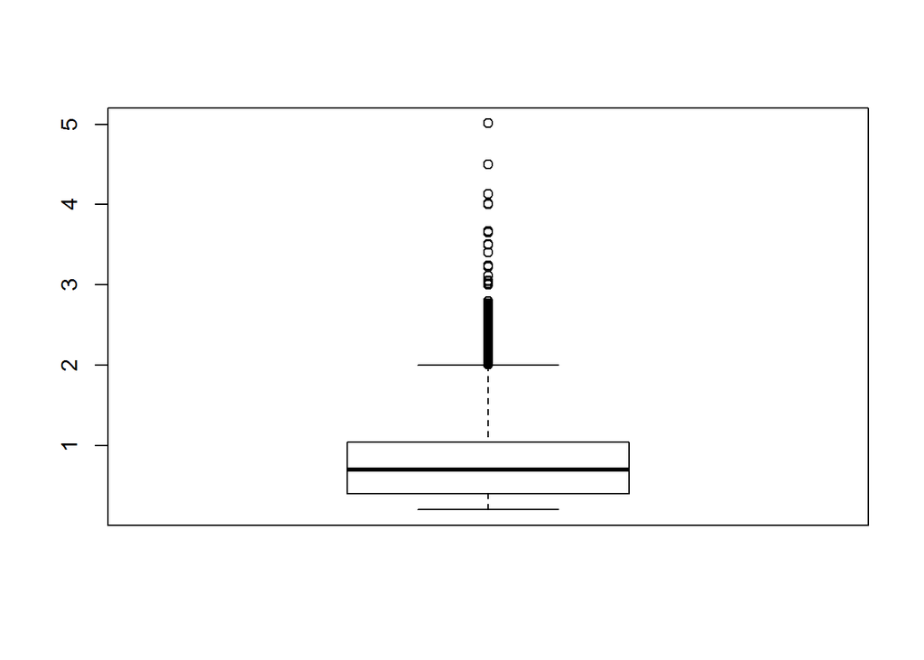

```r
boxplot(diamonds$carat)
```

# 3 利用ggplot2画图

## 3.1 直方图

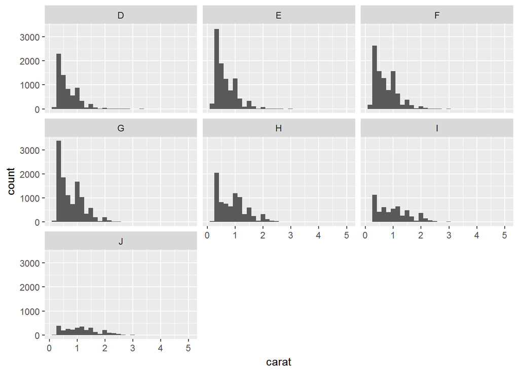

```r
ggplot(data=diamonds,aes(x=carat))+geom_histogram()+facet_wrap(~color)
```

facet_wrap(~color) 是指在一张图上按color分类画多个小图

## 3.2 散点图

先把绘图框画出来 按照color分类画点，不同color不同颜色

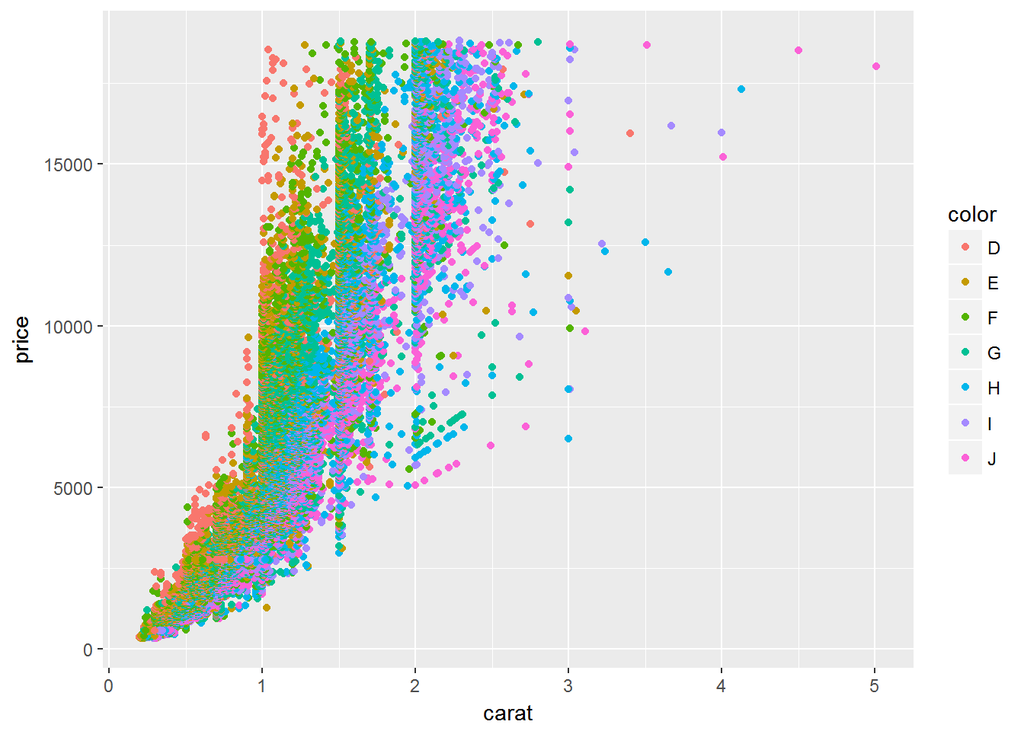

```r
g=ggplot(diamonds,aes(x=carat,y=price))
g+geom_point(aes(color=color))
```

对不同color画不同的小图

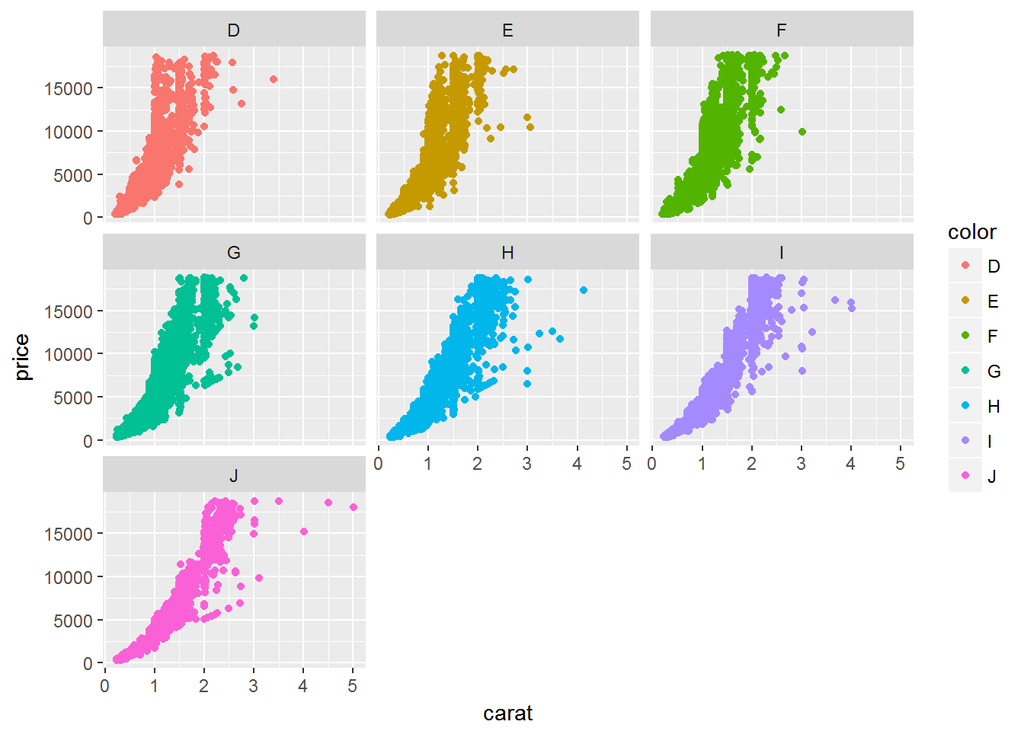

```r
g+geom_point(aes(color=color))+facet_wrap(~color)
```

*散点图上加直线*

```r
library(gcookbook)
p=ggplot(heightweight,aes(x=ageYear,y=heightIn,colour=sex))+geom_point()
```

加上坐标轴，自定义位置 geom_hline()加上横轴线，geom_vline()加上纵轴线

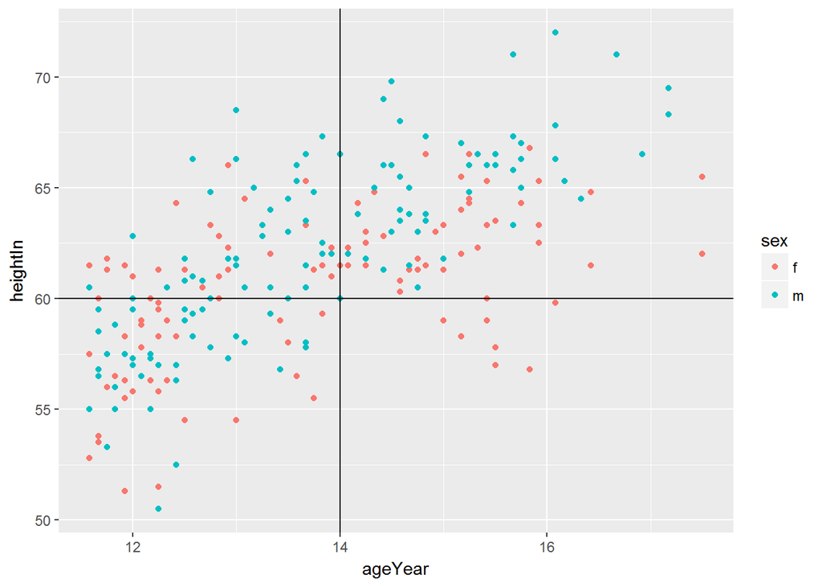

```r
p+geom_hline(yintercept = 60)+geom_vline(xintercept = 14)
```

在散点图上加一条斜线 linetype=“dashed”线段

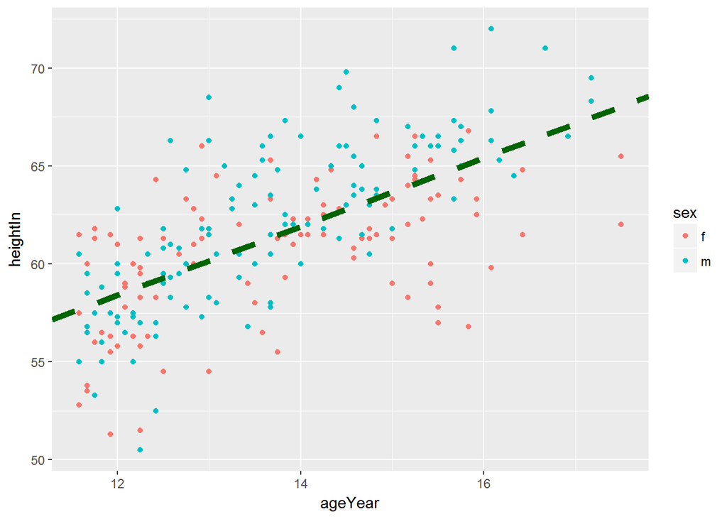

```r
p+geom_abline(intercept = 37.4,slope=1.75,linetype="dashed",size=2,colour="darkgreen")
```

## 3.3 箱线图

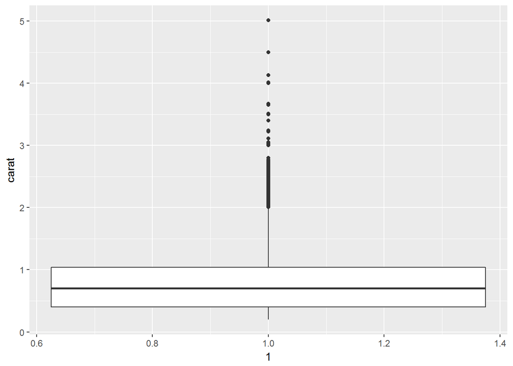

```r
ggplot(diamonds,aes(y=carat,x=1))+geom_boxplot()
```

按cut分类画多个小箱线图

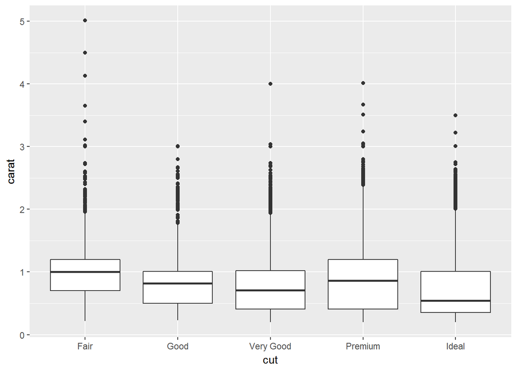

```r
ggplot(diamonds,aes(y=carat,x=cut))+geom_boxplot()
```

boxplot表现出，切得完美的carat数比较小；and carat的中位数随着cut变化递减，但premium 的中位数上升一点，原因可能是因为：在大多数人能切成premium的情况下，再将premium切成ideal成本过高。

## 3.4 二维密度图

绘制2D等高线主要是调用stat_density函数。这个函数会给出一个基于数据的二维核密度估计，然后我们可基于这个估计值来判断各样本点的“等高”性。 colour设置等高线颜色，使用..level..，将密度曲面的高度映射给等高线的颜色，衡量数据分布的密集情况是通过默认的等高线展示。

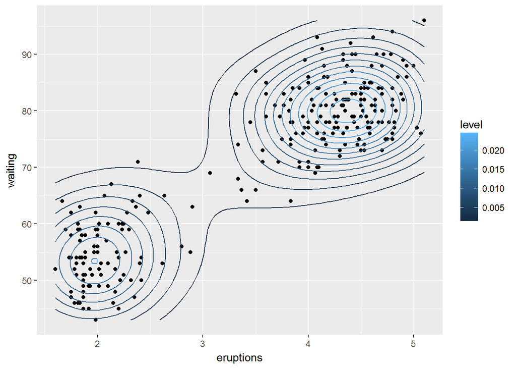

```r
p= ggplot(faithful,aes(x=eruptions,y=waiting))
p+geom_point()+ stat_density2d(aes(colour=..level..))
```

将密度估计映射给透明度，alpha表示透明度，其数据为密度

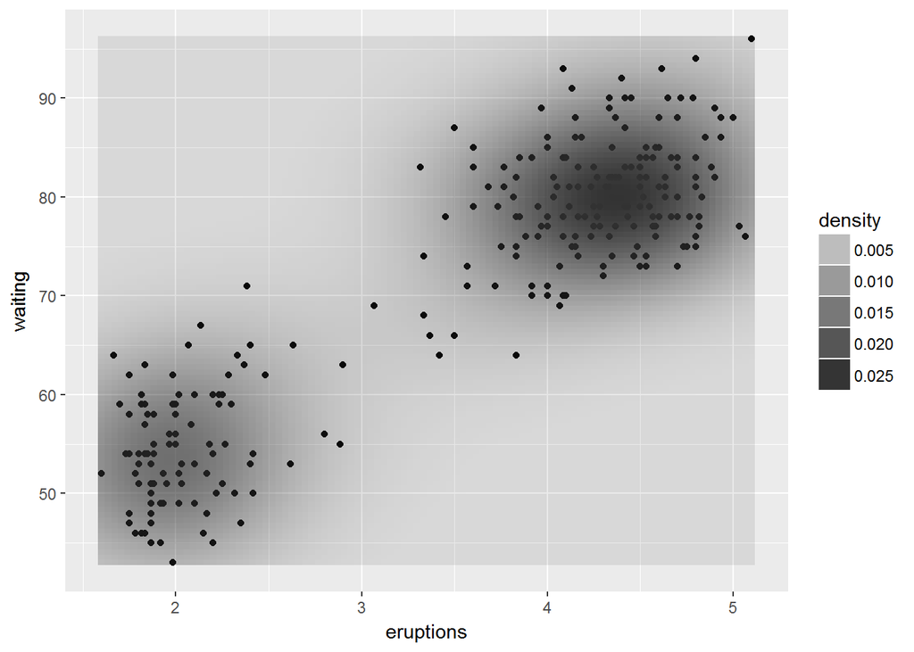

```r
p+geom_point()+ stat_density2d(aes(alpha=..density..),geom="tile",contour = F)
```

也可以选择瓦片图展示数据的分布情况

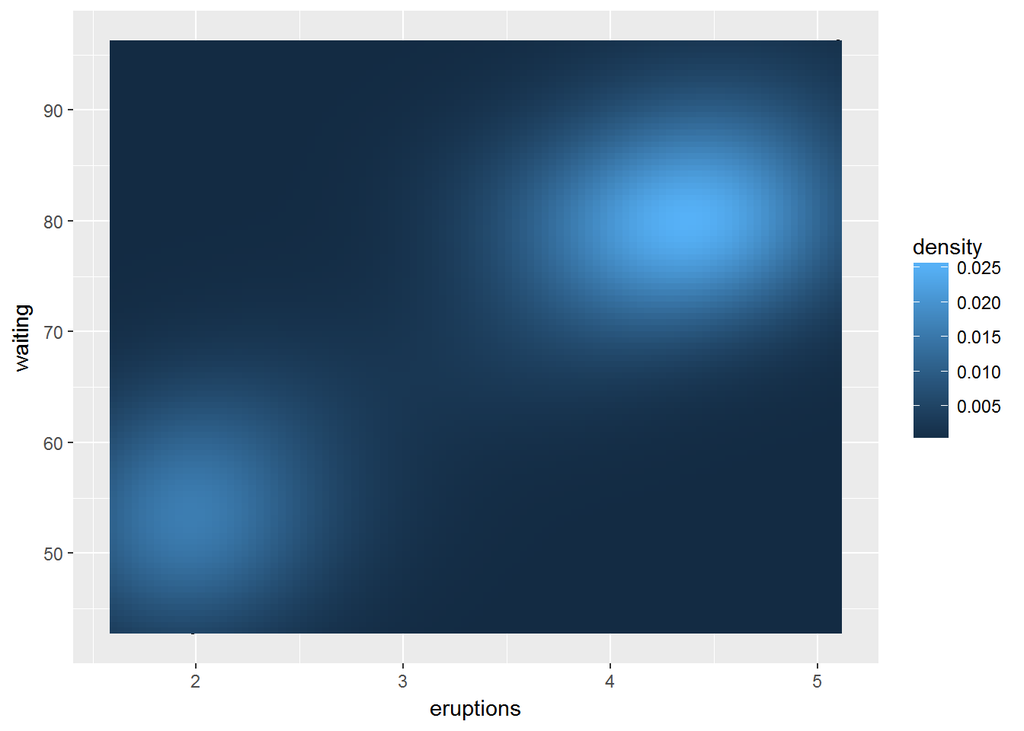

```r
p+geom_point()+ stat_density2d(aes(fill=..density..),geom="tile",contour = F)
```

绘制二维数据的密度图并加上解释

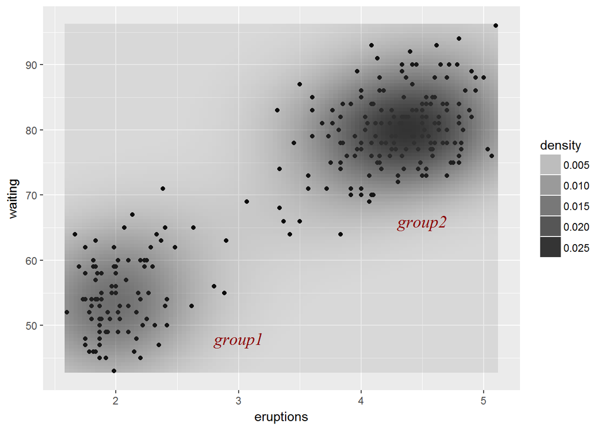

```r
p1=p+geom_point()+stat_density2d(aes(alpha=..density..),geom="tile",contour=F)
p1+annotate("text",x=3,y=48,label="group1",family="serif",fontface="italic",colour="darkred",size=5)+
  annotate("text",x=4.5,y=66,label="group2",family="serif",fontface="italic",colour="darkred",size=5)
```

fontface/family 都是调字体 darkred 深红色

## 3.5 条形图

直方图：离散型变量 条形图：连续型变量 Geom_bar 条形图

### 3.5.1 普通条形图

```r
library(gcookbook)
str(BOD)
```

```
## 'data.frame':    6 obs. of  2 variables:
##  $ Time  : num  1 2 3 4 5 7
##  $ demand: num  8.3 10.3 19 16 15.6 19.8
##  - attr(*, "reference")= chr "A1.4, p. 270"
```

绘图函数里的stat参数表示对样本点做统计的方式，即指统计变换，默认为identity，表示一个x对应一个y，是指不进行统计变换，即demand就是纵坐标值,也就是说identity提取横坐标x对应的y值

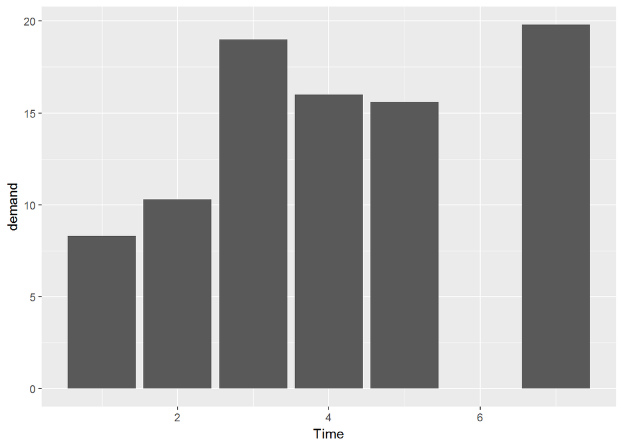

```r
ggplot(BOD,aes(x=Time,y=demand))+geom_bar(stat="identity")
```

同时还可以是stat=bin或者stat=count，表示一个x对应落到该x的样本数。也就是说bin、count提取横坐标x的频数,此时ggplot中的aes不应有y变量。geom_bar中的colour是指的每一个bar的外框颜色,该参数默认情况下是灰色

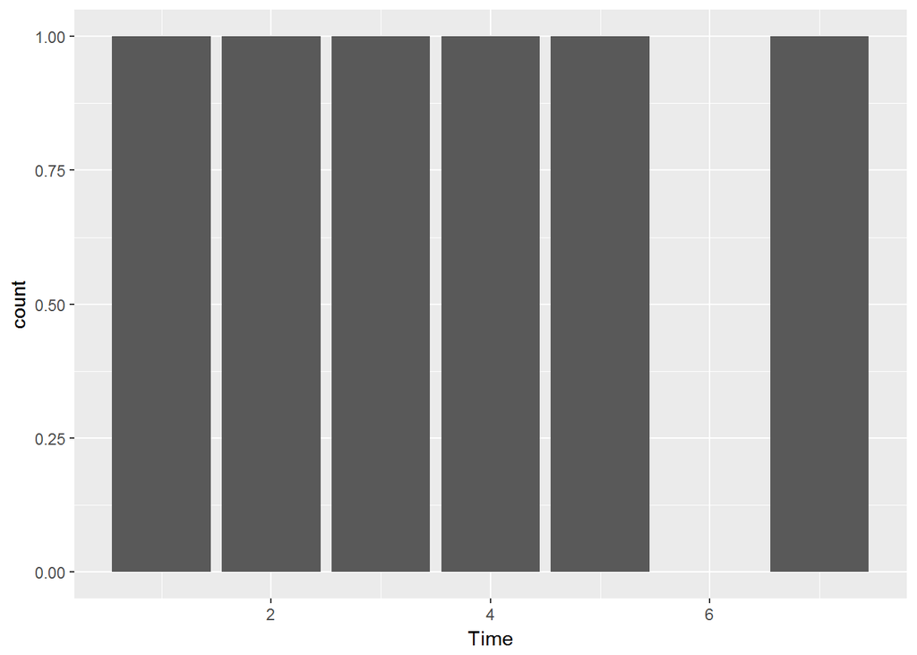

```r
ggplot(BOD,aes(x=Time))+geom_bar(stat="count")
```

发现时间为6时无数据，为作图把6列去掉，对xfactor化

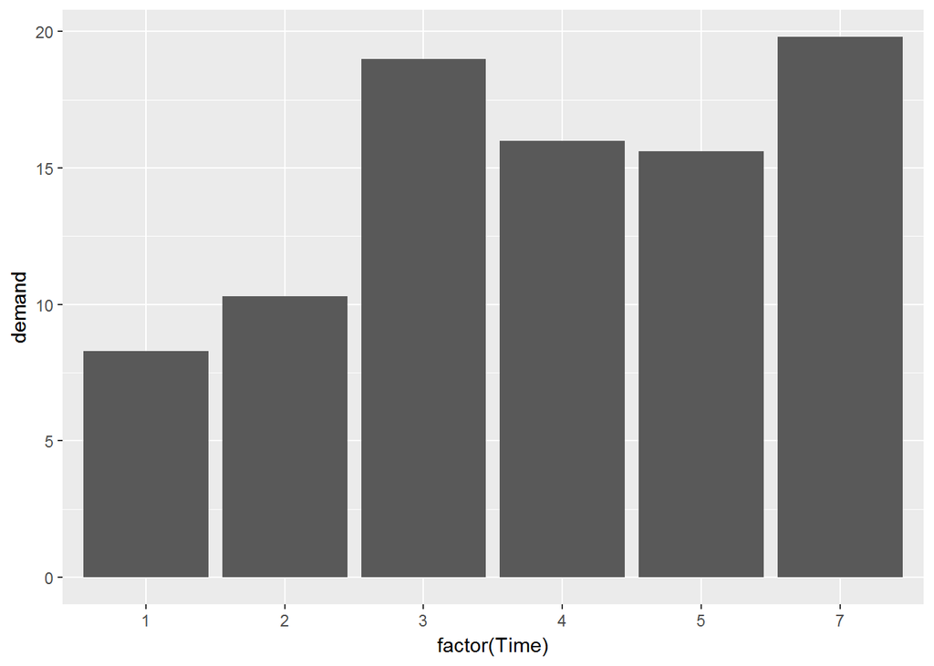

```r
ggplot(BOD,aes(x=factor(Time),y=demand))+geom_bar(stat="identity")
```

另一组数据进行演示 Fill 填充的颜色，Color 边界颜色

```r
str(pg_mean)
```

```
## 'data.frame':    3 obs. of  2 variables:
##  $ group : Factor w/ 3 levels "ctrl","trt1",..: 1 2 3
##  $ weight: num  5.03 4.66 5.53
```

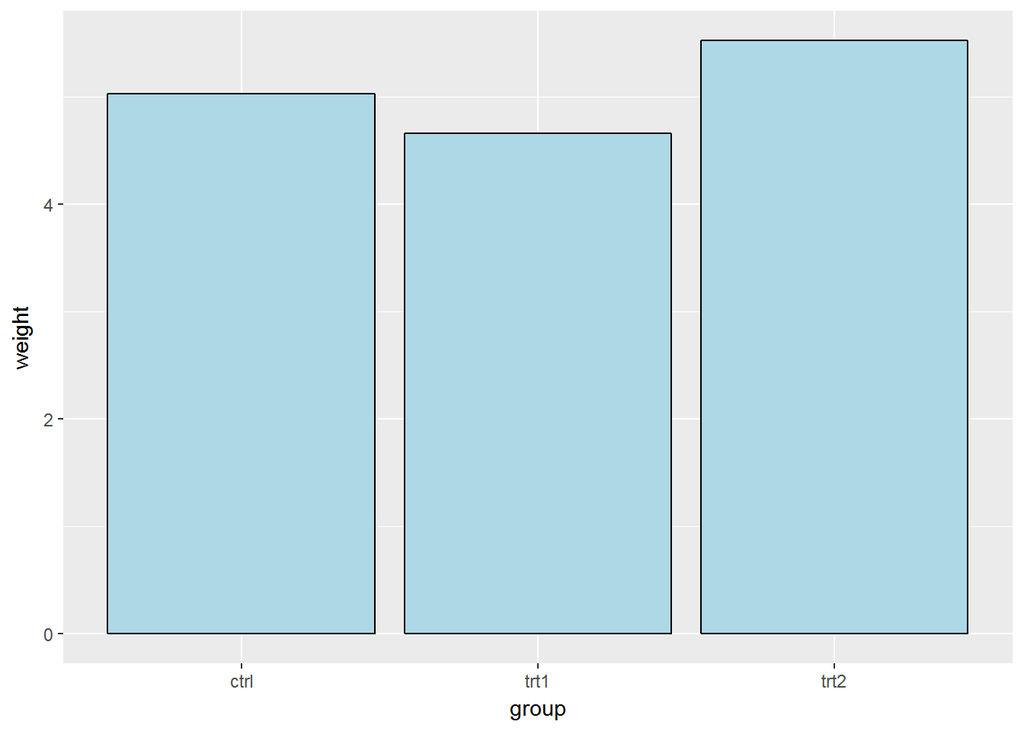

```r
ggplot(pg_mean,aes(x=group,y=weight))+geom_bar(stat="identity",fill="lightblue",colour="black")
```

### 3.5.2 分组条形图

分组fill写在aes里，poisition=“dodge”,bar记得写stat

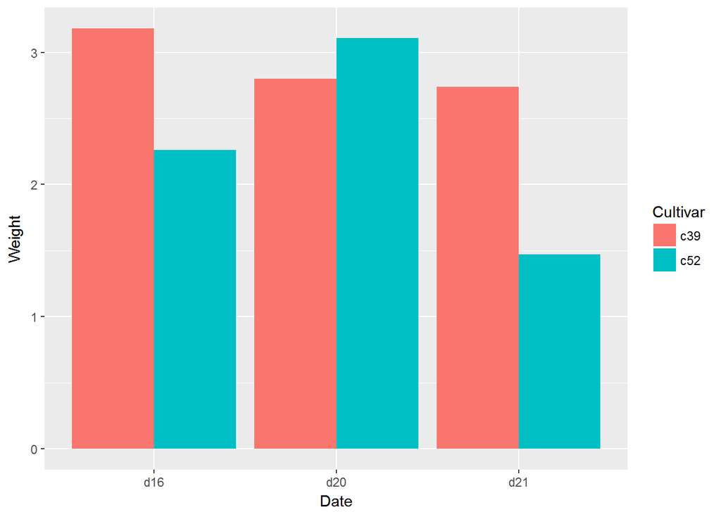

```r
ggplot(cabbage_exp,aes(x=Date,y=Weight,fill=Cultivar))+geom_bar(position="dodge",stat="identity")
```

折叠款

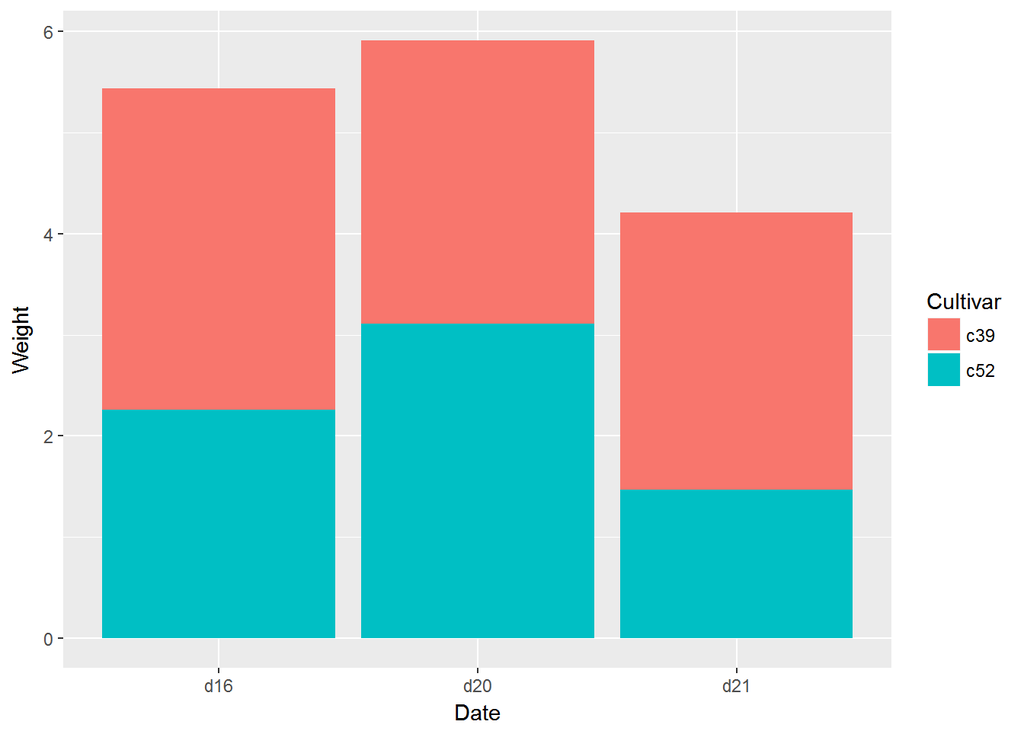

```r
ggplot(cabbage_exp,aes(x=Date,y=Weight,fill=Cultivar))+geom_bar(stat="identity")
```

*另一组数据uspopchange* 在大数据中取自己作图:subset

```r
upc=subset(uspopchange,rank(Change)>40)
head(upc)
```

```
##       State Abb Region Change
## 3   Arizona  AZ   West   24.6
## 6  Colorado  CO   West   16.9
## 10  Florida  FL  South   17.6
## 11  Georgia  GA  South   18.3
## 13    Idaho  ID   West   21.1
## 29   Nevada  NV   West   35.1
```

Scale_fill_manual（values=c(“#…”)）填充颜色 Reorder()把一个变量根据另一个变量排序

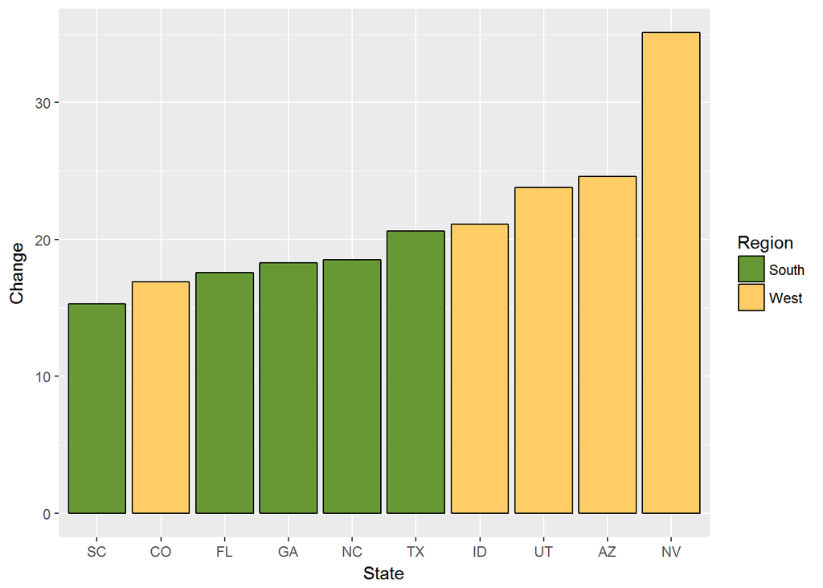

```r
ggplot(upc,aes(x=reorder(Abb,Change),y=Change,fill=Region)) +geom_bar(stat="identity",colour="black")+scale_fill_manual(values=c("#669933","#FFcc66"))+xlab("State")
```

*另一组数据climate*

```r
head(climate)
```

```
##     Source Year Anomaly1y Anomaly5y Anomaly10y Unc10y
## 1 Berkeley 1800        NA        NA     -0.435  0.505
## 2 Berkeley 1801        NA        NA     -0.453  0.493
## 3 Berkeley 1802        NA        NA     -0.460  0.486
## 4 Berkeley 1803        NA        NA     -0.493  0.489
## 5 Berkeley 1804        NA        NA     -0.536  0.483
## 6 Berkeley 1805        NA        NA     -0.541  0.475
```

```r
csub=subset(climate,Source=="Berkeley"&Year>=1900)
head(csub)
```

```
##       Source Year Anomaly1y Anomaly5y Anomaly10y Unc10y
## 101 Berkeley 1900        NA        NA     -0.171  0.108
## 102 Berkeley 1901        NA        NA     -0.162  0.109
## 103 Berkeley 1902        NA        NA     -0.177  0.108
## 104 Berkeley 1903        NA        NA     -0.199  0.104
## 105 Berkeley 1904        NA        NA     -0.223  0.105
## 106 Berkeley 1905        NA        NA     -0.241  0.107
```

```r
csub$pos=csub$Anomaly10y<=0
head(csub)
```

```
##       Source Year Anomaly1y Anomaly5y Anomaly10y Unc10y  pos
## 101 Berkeley 1900        NA        NA     -0.171  0.108 TRUE
## 102 Berkeley 1901        NA        NA     -0.162  0.109 TRUE
## 103 Berkeley 1902        NA        NA     -0.177  0.108 TRUE
## 104 Berkeley 1903        NA        NA     -0.199  0.104 TRUE
## 105 Berkeley 1904        NA        NA     -0.223  0.105 TRUE
## 106 Berkeley 1905        NA        NA     -0.241  0.107 TRUE
```

csub$pos 增加一个逻辑型变量

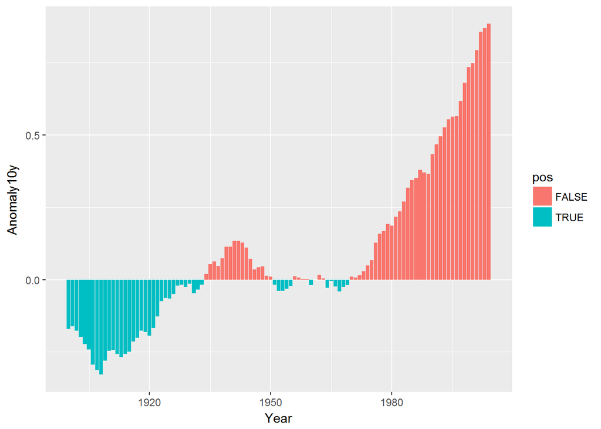

```r
ggplot(csub,aes(x=Year,y=Anomaly10y,fill=pos))+geom_bar(stat="identity",position = "identity")
```

position位置调整：stack、dodge、fill、identity、jitter

```r
cusb3=subset(climate,Year>=1900&Year<=1901)
```

(1)identity方式是不做任何改变直接显示出来，所以需要设置透明度才能看得清楚

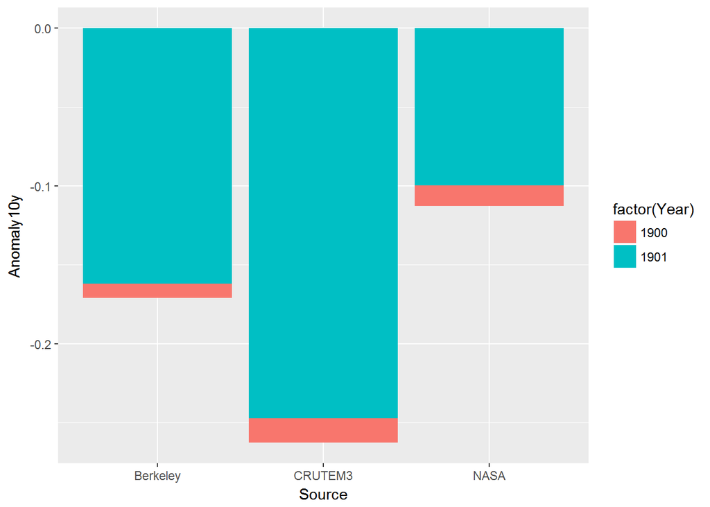

```r
 ggplot(cusb3,aes(x=Source,y=Anomaly10y,fill=factor(Year)))+geom_bar(stat="identity",position="identity")
```

(2)stack方式是将不同年份数据堆叠放置，是geom_bar的默认处理方式

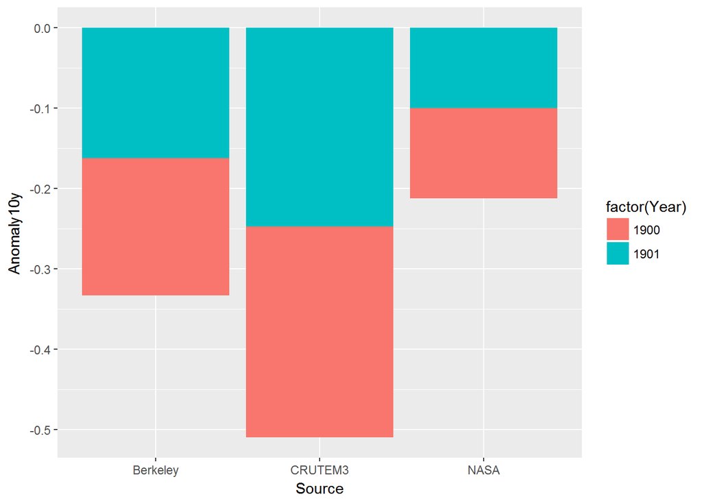

```r
 ggplot(cusb3,aes(x=Source,y=Anomaly10y,fill=factor(Year)))+geom_bar(stat="identity",position="stack")
```

(3)dodge方式是将不同年份的数据并列放置；

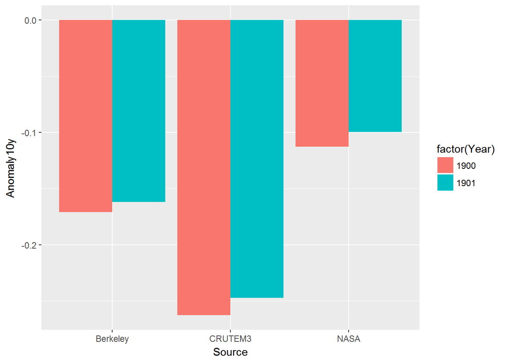

```r
ggplot(cusb3,aes(x=Source,y=Anomaly10y,fill=factor(Year)))+geom_bar(stat="identity",position="dodge")
```

(4)fill方式和stack类似，但Y轴不再是计数，而是以百分比显示

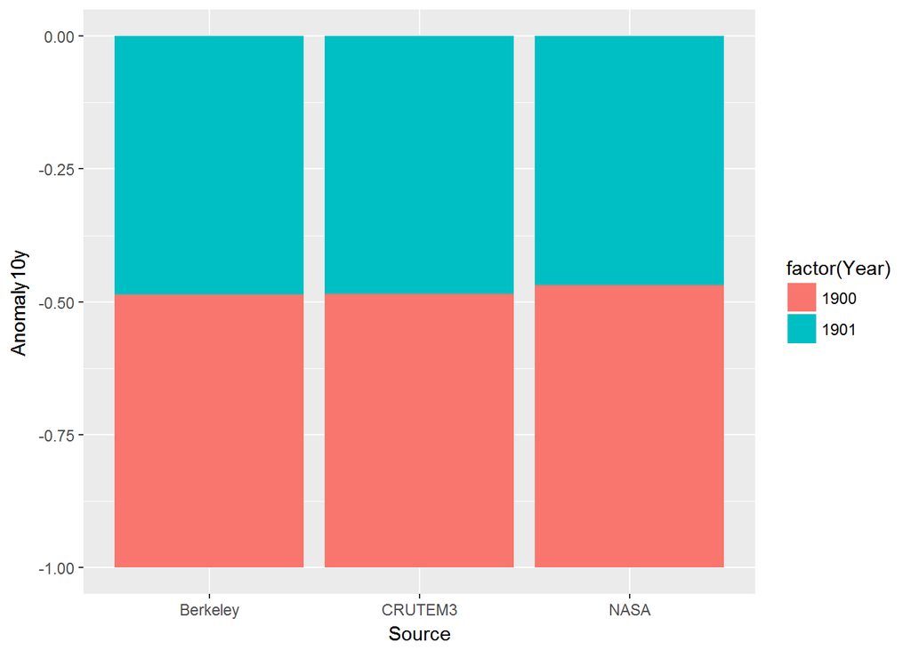

```r
ggplot(cusb3,aes(x=Source,y=Anomaly10y,fill=factor(Year)))+geom_bar(stat="identity",position="fill")
```

## 3.6 在图上进行标注

```r
library(grid)
p=ggplot(subset(climate,Source=="Berkeley"),aes(x=Year,y=Anomaly10y))+geom_line()
```

p=ggplot(subset(climate,Source==“Berkeley”),aes(x=Year,y=Anomaly10y))+geom_line() 画出折线图 Library(grid) 网格 ###annotate annotate中的类型有：text文本、rect阴影矩形、segment线段 （1）类型为segment 时，后需加线段端点的坐标

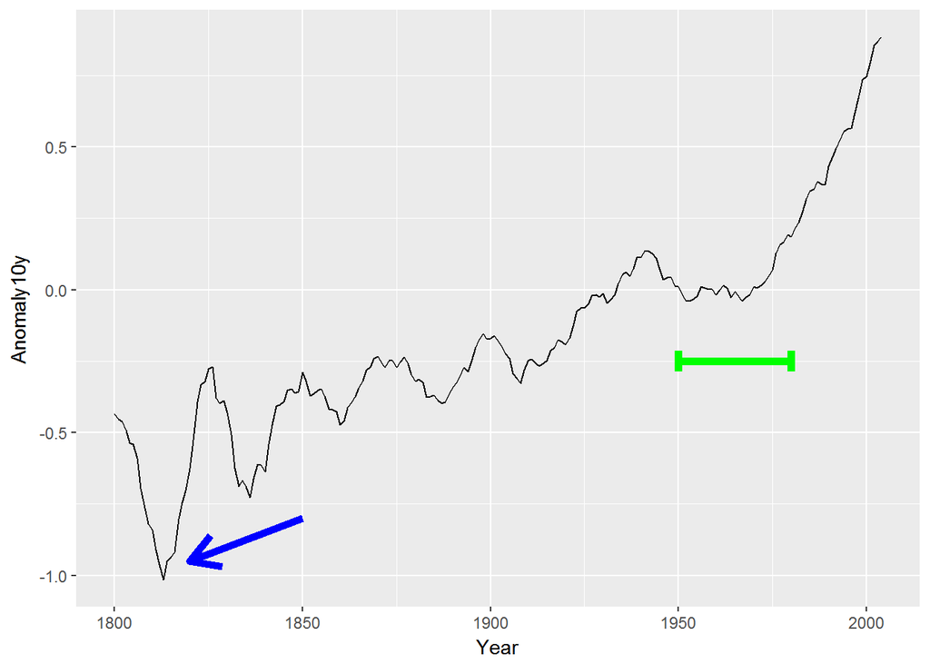

```r
p+annotate("segment",x=1850,xend=1820,y=-0.8,yend=-0.95,colour="blue",size=2,arrow=arrow())+
  annotate("segment",x=1950,xend=1980,y=-0.25,yend=-0.25,colour="green",size=2,arrow=arrow(ends="both",angle=90,length = unit(0.2,"cm")))
```

线段端点坐标：x=1850，xend=1820,y=-0.8,yend=-0.95 grid包中的arrow可以为segment线段添加箭头，箭头的方向就是xy的方向 arrow() 不填内容则默认为单向箭头，方向是last的方向 arrow(angle=,length,ends,type=) angle 箭头的角度；length是指箭头的长度， ends=last/first/both: 反正就箭头的方向 type=open/closed:closed指箭头是一个封闭的三角形

(2)类型为rect时，指在图中生成一个阴影矩阵（用alpha来调节阴影透明度）后需加四个点的坐标，fill确定填充的颜色

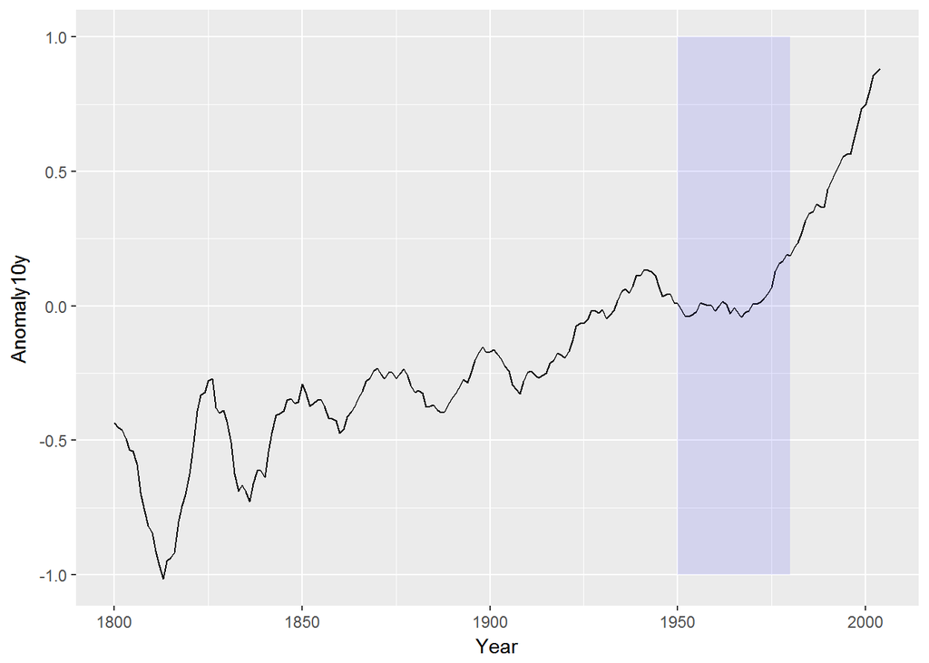

```r
p + annotate("rect", xmin=1950, xmax=1980, ymin=-1, ymax=1, alpha=.1, fill="blue")
```

(3)类型为txt时，指在图中加文字标注，后加文字起始坐标，内容用label=“”添加，也可用geom_text添加文字标注

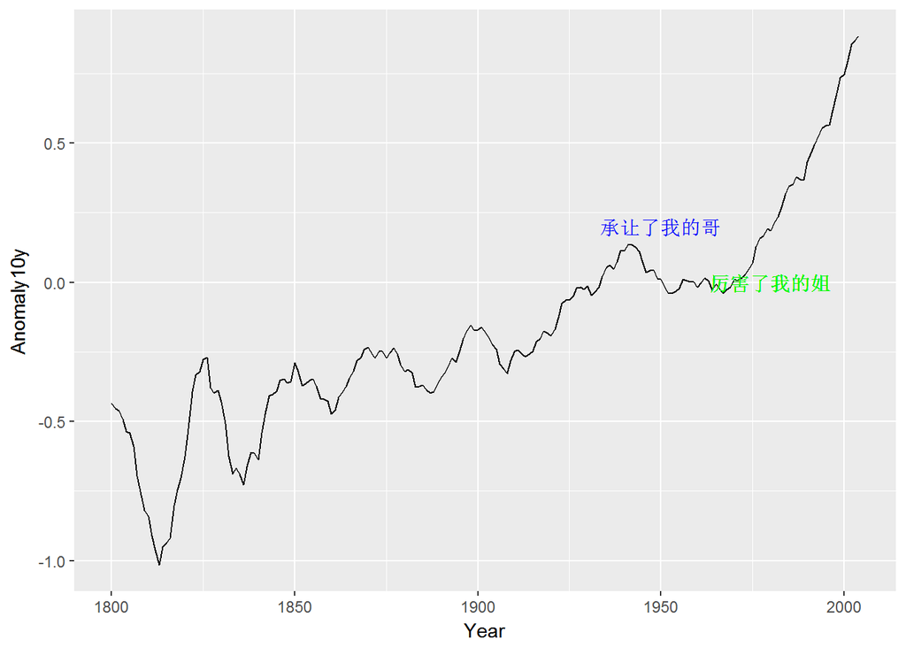

```r
p + annotate("text", x=1950, y=0.2, label="承让了我的哥", alpha=1,colour="blue") +     # Normal
    geom_text(x=1980, y=0, label="厉害了我的姐", alpha=.1,colour="green")            # Overplotted
```

*在图中添加数学公式*

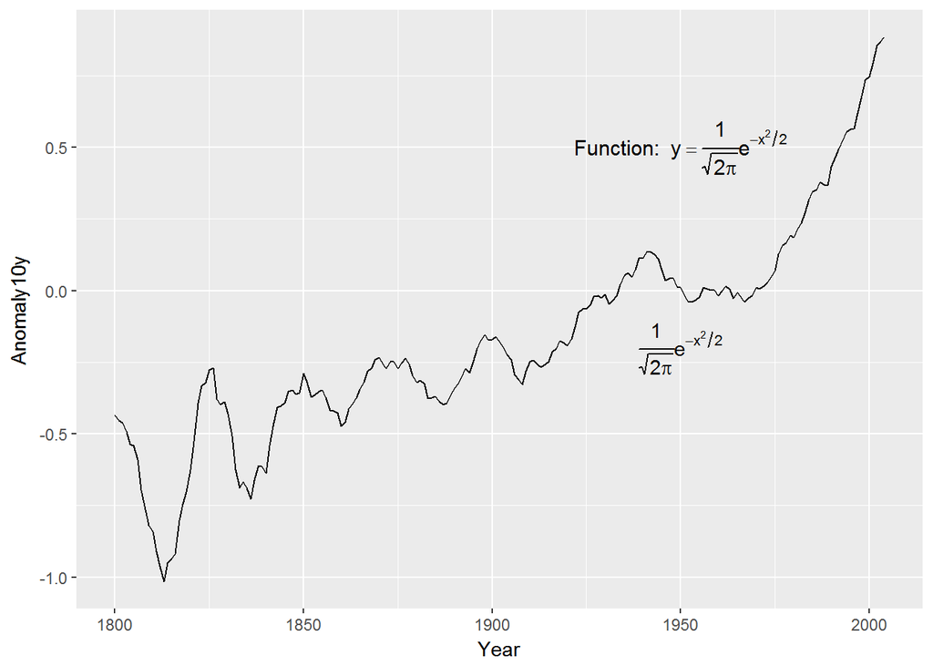

```r
p + annotate("text", x = 1950, y = 0.5, parse = TRUE, size = 4, label = "'Function:  ' * y==frac(1, sqrt(2*pi)) * e^{-x^2/2}" )+
 annotate("text", x = 1950, y = -0.2, parse = TRUE, label = "frac(1, sqrt(2 * pi)) * e ^ {-x^2 / 2}")
```

注意：parse=TRUE 用*在两部分之间进行连接 普通的文字用单引号引起来

### 3.6.1 geom_text

*在条形图上标数据*

```r
library(plyr)
ce<-ddply(cabbage_exp,"Date",transform,percent_Weight=Weight/sum(Weight)*100)
head(ce)
```

```
##   Cultivar Date Weight        sd  n         se percent_Weight
## 1      c39  d16   3.18 0.9566144 10 0.30250803       58.45588
## 2      c52  d16   2.26 0.4452215 10 0.14079141       41.54412
## 3      c39  d20   2.80 0.2788867 10 0.08819171       47.37733
## 4      c52  d20   3.11 0.7908505 10 0.25008887       52.62267
## 5      c39  d21   2.74 0.9834181 10 0.31098410       65.08314
## 6      c52  d21   1.47 0.2110819 10 0.06674995       34.91686
```

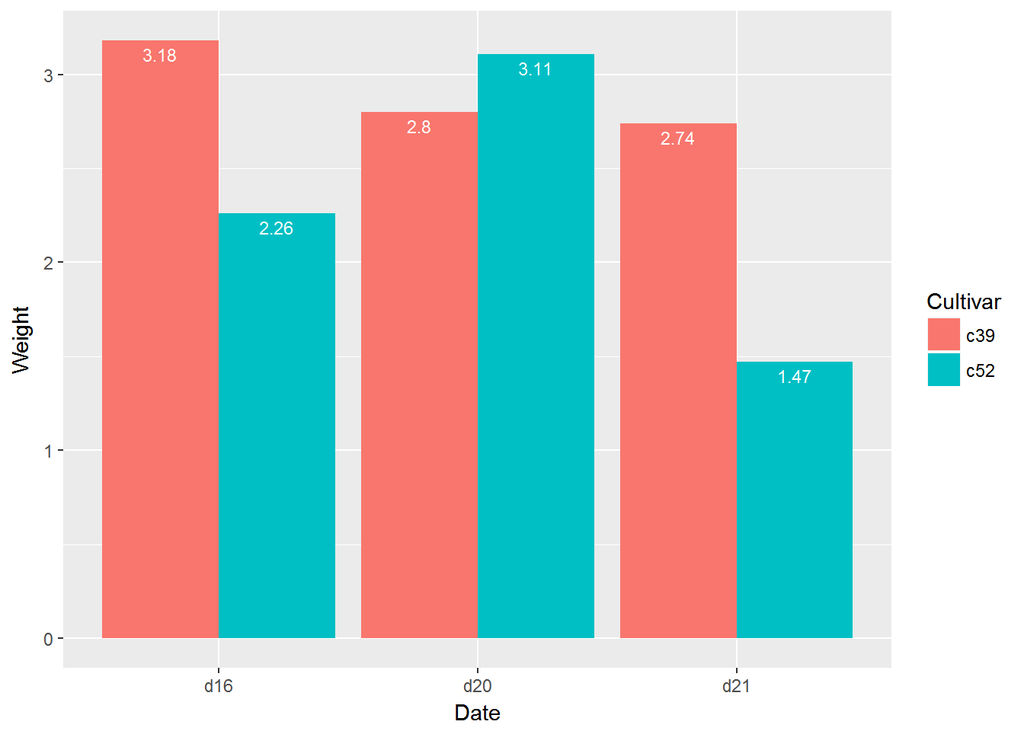

```r
ggplot(ce,aes(x=Date,y=Weight,fill=Cultivar))+geom_bar(stat="identity",position="dodge")+geom_text(aes(label=Weight),vjust=1.5,colour="white",position = position_dodge(.9),size=3)
```

1.对于水平交错的簇条形图(即bar中的position=“dodge”)，必须通过geom_text()函数中的position_dodge()参数来调整标签位置，position_dodge(width),此时的width为两个文字标签之间的宽度 2.geom_bar()函数中的position = ’stack’参数，标签位置geom_text()函数中的position = position_stack()参数.

geom_text()中的size为字体大小,colour更换标签颜色, vjust调整标签位置，1为分界线，越大于1，标签越在条形图上界*下方*，反之则越在条形图上上界上方。 vjust>0时是标签向下调整,hjust=0.5将标签水平居中放置. 关于geom_text参数，可以参考：http://www.sohu.com/a/125919313_466874

## 3.7 折线图

```r
head(ToothGrowth)
```

```
##    len supp dose
## 1  4.2   VC  0.5
## 2 11.5   VC  0.5
## 3  7.3   VC  0.5
## 4  5.8   VC  0.5
## 5  6.4   VC  0.5
## 6 10.0   VC  0.5
```

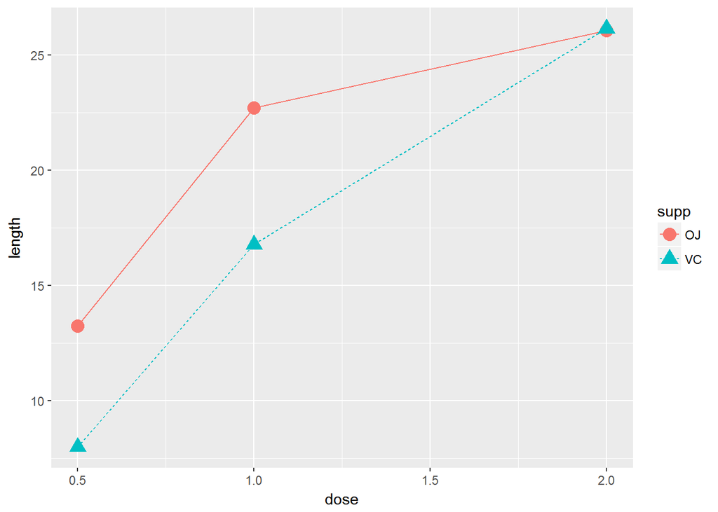

```r
tg<-ddply(ToothGrowth,c("supp","dose"),summarise,length=mean(len))
ggplot(tg,aes(x=dose,y=length,linetype=supp,colour=supp,shape=supp))+geom_line()+geom_point(size=4)
```